# Cell size data routine checks

# Data import and setup

Libraries and data import and removing irrelevant data

> Checking that the dimensions make sense for each species. On second thought though I think this would be best to check in excel to make sure I change errors to the right dimension (like would ‘l’ for dity really be h or w?)

Filtering and checking numbers of observations by treatments and then by each plate/well combination

**so far this is total obs not total number of cells so maybe move to after pivoting and mutating stuff**

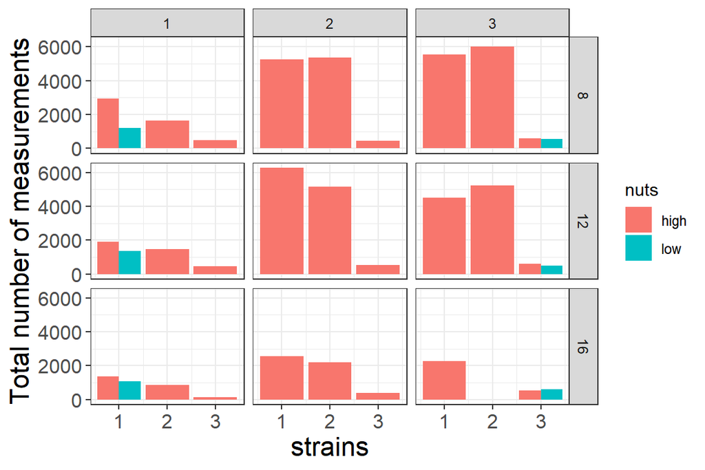

```r
#checks where data is generally sparse or not

grouped <- sizechecks %>% group_by(nuts, temp, species_richness, strains) %>%
  summarize(count=n())

ggplot(grouped, aes(strains, count))+
  geom_col(aes(fill=nuts), position = 'dodge')+
  facet_grid(temp~species_richness)+
  ylab('Total number of measurements')
```

```r
#checks which wells have been done already

grouped2 <- sizechecks %>% group_by(plate, well, species_richness, strains, nuts, temp) %>%
  summarize(count=n())
```

Check where the problems are so pivot_wider doesn’t drive me crazy

```r
#makes an object of all the cell_ids that appear too many times

cell_id_checks <- sizechecks %>%
  count(cell_id) %>%
  filter(n>2)

FIX <- nrow(cell_id_checks)

biovolumes_wide <- sizechecks %>%
  pivot_wider(names_from = dimension,
              values_from = distance,
              values_fn = length, # THIS GIVES THE LENGTH, not actual values, just for checking data
              id_cols = cell_id)

#not sure why this gives a different number than the chunk above where it gives 56 with too many cell_ids, this gives 174??
```

Using pivot wider to check if there are errors with cell_id (more than one or 2 per cell id = problematic)

```r
biovolumes_wide_check_counts <- biovolumes_wide %>% filter(h>1 | w>1 | d>1 | h>1)
```

> For now, attempting to exclude ones where the cell_ids are weird, but for the final analysis need to either manually fix those in excel, since that might be tough to do in R

> And even after I exclude the weird ones it still gives issues with pivot_wider :/

```r
#join the object with all the weird cell_ids and filter those out since those are the only nas, which gets ride of a couple hundred rows
biovolumes_wide_clean <- left_join(sizechecks, cell_id_checks) %>%
  filter(is.na(n))

biovolumes_wide_clean2 <- biovolumes_wide_clean %>%
  pivot_wider(names_from = dimension,
              values_from = distance, values_fn=length)

biovolumes_wide_check_counts <- biovolumes_wide_clean2 %>% filter(h>1 | w>1 | d>1 | h>1)

bad <- biovolumes_wide_check_counts[11] %>%
  mutate(badrows='bad')

biovolumes_wide_clean3 <- left_join(sizechecks, bad) %>%
  filter(is.na(badrows))

biovolumes_wide_clean4 <- biovolumes_wide_clean3 %>%
  select(cell_id, dimension, distance) %>%
  pivot_wider(names_from = dimension,
              values_from = distance)
```

> Since pivot_wider is being really shitty, I’ll just take the mean values for things that are weird, but this needs to be fixed. for preliminary work only about 0.12% are weird so this can be temporarily ignored

```r
biovolumes_wide <- sizechecks %>%
  pivot_wider(names_from = dimension,
              values_from = distance,
              values_fn = mean) #mean == wrong, so do it right later
              #id_cols = cell_id)
```

Separating the broken vs non-broken cells, separating species

```r
notbroken <- filter(biovolumes_wide, is.na(broken))
broken <- biovolumes_wide %>% filter(broken==1)
```

Attempting to deal with the broken cells correctly

1. make objects for each species
2. calculate mean ratio of measured dimensions
3. use mutate to calculate unmeasured dimensions

```r
dity_intact <- subset(notbroken, species=="dity")
rhizo_intact <- subset(notbroken, species=="rhizo")
tnema_intact <- subset(notbroken, species=="tnema")

dity_mean_ratio <- mean(dity_intact$h/dity_intact$w, na.rm = TRUE)

rhizo_mean_ratio <- mean(rhizo_intact$h/rhizo_intact$d, na.rm=TRUE)

tnema_mean_ratio <- mean(tnema_intact$l/tnema_intact$h, na.rm = TRUE)

broken <- broken %>%
  mutate(h = ifelse(species=='dity', w*dity_mean_ratio, h)) %>%
  mutate(h = ifelse(species=='rhizo', d*rhizo_mean_ratio, h)) %>%
  mutate(l = ifelse(species=='tnema', h*tnema_mean_ratio, l))

biovolumes_with_broken <- bind_rows(dity_intact, rhizo_intact, tnema_intact, broken)

biovolumes_with_broken <- biovolumes_with_broken %>%
  mutate(biov='NA') %>%
  mutate(biov = ifelse(species=='dity', w*w*h/2, biov)) %>%
  mutate(biov = ifelse(species=='rhizo', (pi/4)*d^2*h, biov)) %>%
  mutate(biov = ifelse(species=='tnema', l*h*h, biov)) %>%
  mutate(biov=as.integer(biov))

biovolumes_with_broken <- biovolumes_with_broken %>%
  mutate(AR ='NA') %>%
  mutate(AR = ifelse(species=='dity', h/w, AR)) %>%
  mutate(AR = ifelse(species=='rhizo', h/d, AR)) %>%
  mutate(AR = ifelse(species=='tnema', l/h, AR)) %>%
  mutate(AR=as.numeric(AR))
```

```r
biovolumes_with_broken <- biovolumes_with_broken %>%
  mutate(fullname = "NA") %>%
  mutate(fullname = ifelse(div_tx=='DB', 'Ditylum (Borkum)', fullname))%>%
  mutate(fullname = ifelse(div_tx=='DH', 'Ditylum (Helgoland)', fullname))%>%
  mutate(fullname = ifelse(div_tx=='DK', 'Ditylum (Kiel)', fullname))%>%
  mutate(fullname = ifelse(div_tx=='RB', 'Rhizosolenia (Borkum)', fullname))%>%
  mutate(fullname = ifelse(div_tx=='RH', 'Rhizosolenia (Helgoland)', fullname))%>%
  mutate(fullname = ifelse(div_tx=='RK', 'Rhizosolenia (Kiel)', fullname))%>%
  mutate(fullname = ifelse(div_tx=='TB', 'Thalassionema (Borkum)', fullname))%>%
  mutate(fullname = ifelse(div_tx=='TH', 'Thalassionema (Helgoland)', fullname))%>%
  mutate(fullname = ifelse(div_tx=='TK', 'Thalassionema (Kiel)', fullname))%>%
  mutate(species_full="NA") %>%
  mutate(species_full = ifelse(species=='dity', 'Ditylum brightwelii', species_full))%>%
  mutate(species_full = ifelse(species=='rhizo', 'Rhizosolenia setigera', species_full))%>%
  mutate(species_full = ifelse(species=='tnema', 'Thalassionema nitzschiodes', species_full)) %>%
  mutate(fullname=fct_rev(fullname)) %>%
  mutate(nuts_temp=paste(nuts, temp, sep = "."))
```

```r
mono_biov <- filter(biovolumes_with_broken, species_richness==1, strains==1)

highdiv_biov <- filter(biovolumes_with_broken, species_richness==3, strains==3)
```

# Effects of environment on cell sizes and shapes

## monocultures and sizes

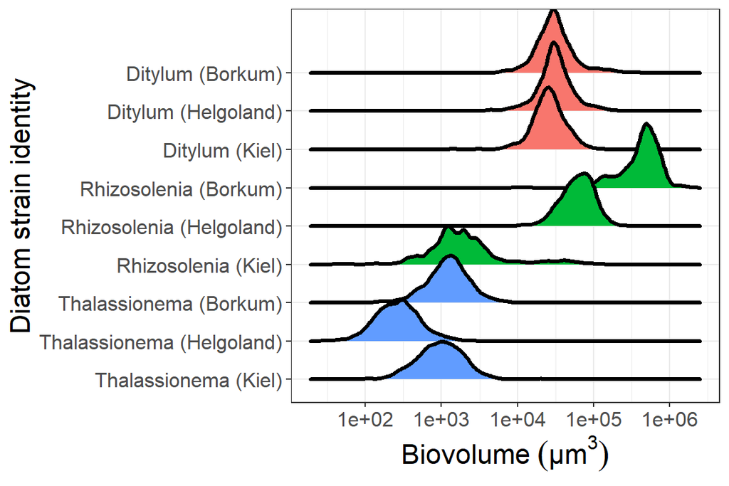

```r
mono_biov$nuts_temp <- ordered(mono_biov$nuts_temp, levels = (c("low.8","low.12","low.16",
                                                            "high.8", "high.12", "high.16")))
highdiv_biov$nuts_temp <- ordered(highdiv_biov$nuts_temp, levels = (c("low.8","low.12","low.16",
                                                            "high.8", "high.12", "high.16")))

ggplot(mono_biov, aes(x = biov, y = fullname))+
  geom_density_ridges(aes(fill=species_full), size = 1.2)+
  scale_x_log10()+
  ylab('Diatom strain identity')+
  xlab(bquote("Biovolume" ~(µm^3)))+
  theme(legend.position = "none")
```

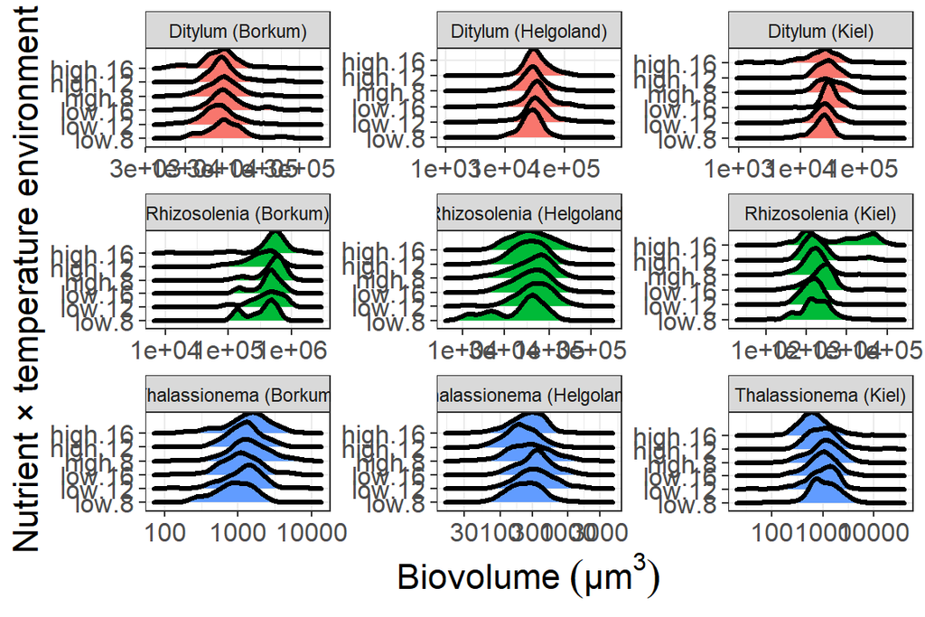

```r
ggplot(mono_biov, aes(x = biov, y = as.factor(nuts_temp)))+
  geom_density_ridges(aes(fill=species_full), size = 1.2)+
  facet_wrap(~fct_rev(fullname), scales = 'free')+
  scale_x_log10()+
  ylab('Nutrient × temperature environment')+
  xlab(bquote("Biovolume" ~(µm^3)))+
  theme(legend.position = "none")
```

##monocultures and shapes

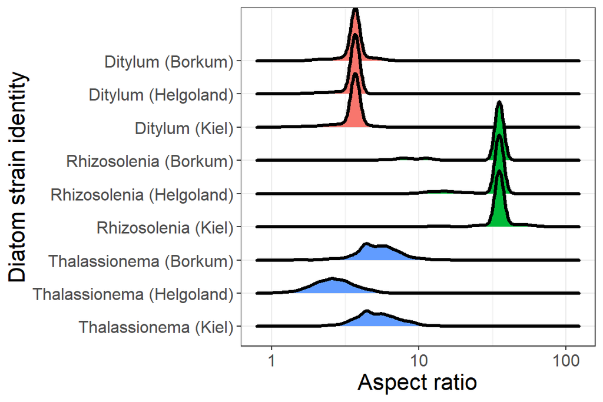

```r
ggplot(mono_biov, aes(x = AR, y = fullname))+
  geom_density_ridges(aes(fill=species_full), size = 1.2)+
  scale_x_log10()+
  ylab('Diatom strain identity')+
  xlab("Aspect ratio")+
  theme(legend.position = "none")
```

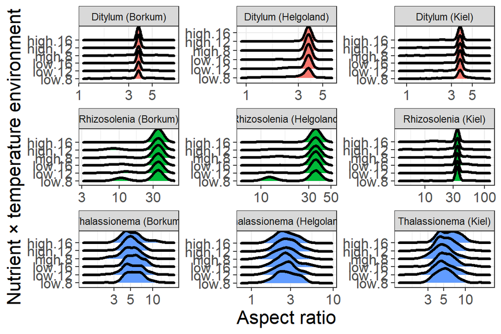

```r
ggplot(mono_biov, aes(x = AR, y = as.factor(nuts_temp)))+
  geom_density_ridges(aes(fill=species_full), size = 1.2)+
  facet_wrap(~fct_rev(fullname), scales = 'free')+
  scale_x_log10()+
  ylab('Nutrient × temperature environment')+
  xlab("Aspect ratio")+
  theme(legend.position = "none")
```

## 3 species 3 strains

Density plots of size by temperature for high diversity treatments

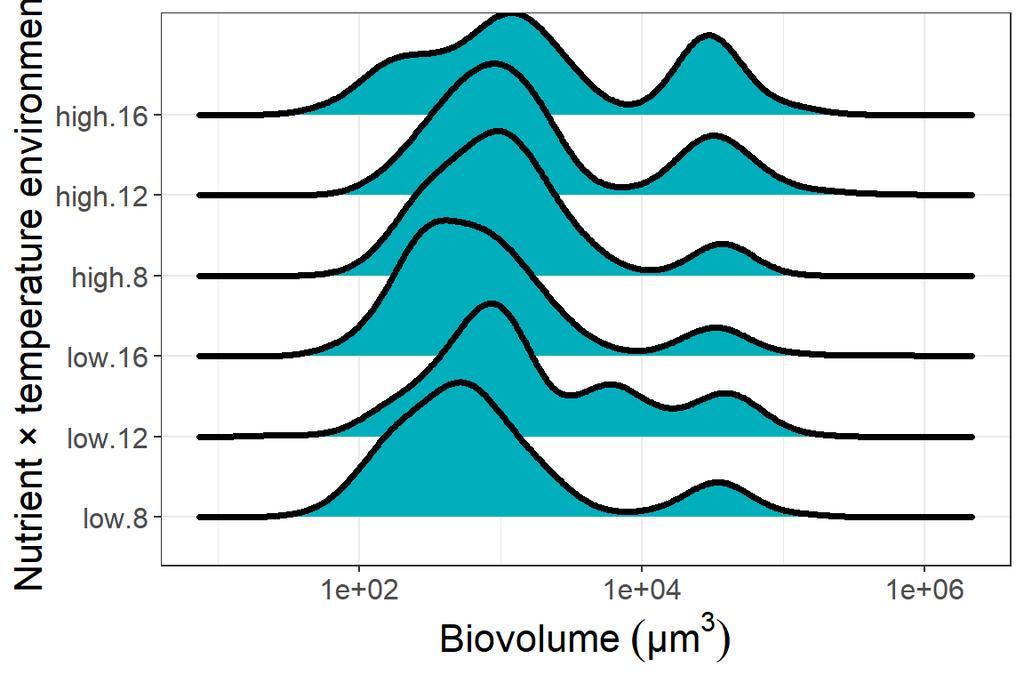

```r
########

ggplot(highdiv_biov, aes(x = biov, y = as.factor(nuts_temp)))+
  geom_density_ridges(fill='#00AFBB', size = 1.4)+
  scale_x_log10()+
  ylab('Nutrient × temperature environment')+
  xlab(bquote("Biovolume" ~(µm^3)))+
  theme(legend.position = "none")
```

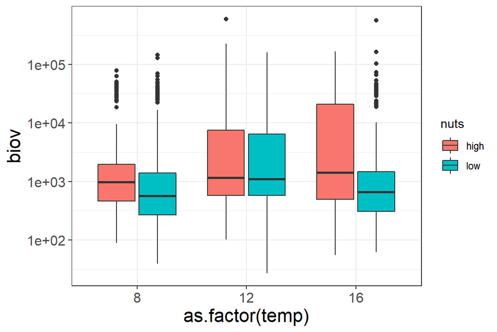

```r
########



ggplot(highdiv_biov, aes(as.factor(temp), biov,  fill=nuts))+
  geom_boxplot()+
  scale_y_log10()
```

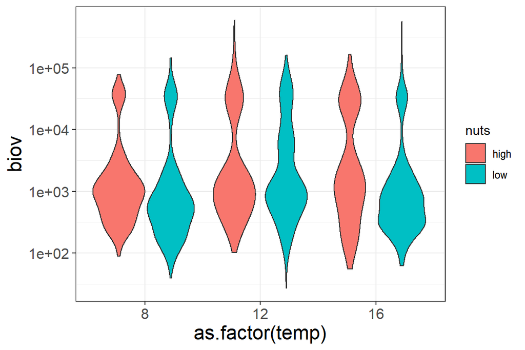

```r
ggplot(highdiv_biov, aes(as.factor(temp), biov,  fill=nuts))+
  geom_violin()+
  scale_y_log10()
```

## All diversity treatments

```r
# ggplot(biovolumes_with_broken, aes(x = biov, y = as.factor(temp)))+
#   geom_density_ridges()+
#   scale_x_log10()
#
# ggplot(biovolumes_with_broken, aes(x = biov, y = as.factor(nuts)))+
#   geom_density_ridges()+
#   scale_x_log10()
#
# ggplot(biovolumes_with_broken, aes(biov))+
#   geom_density()+
#   facet_grid(temp~nuts)+
#   scale_x_log10()
```

# Effects of species and strain richness on size diversity

> not having any fucking luck with left_join today so this shit doesn’t work

```r
size_by_well <- biovolumes_with_broken %>%
  mutate(plate_well = paste(plate, well)) %>%
  group_by(plate, well, plate_well, species_richness, strains,
           temp, nuts, nuts_temp) %>%
  summarize(var_biov=var(biov),
            mean_biov=mean(biov),
            CV_biov=sd(biov)/mean(biov)) %>%
  mutate(plate=as.character(plate)) %>%
  mutate(temp = as.character(temp)) %>%
  filter(!is.na(CV_biov))


size_by_well$nuts_temp <- ordered(size_by_well$nuts_temp, levels = (c("low.8","low.12","low.16","high.8", "high.12", "high.16")))

#allmaxRFUandfits <- read_csv("allmaxRFUandfits17.7.20_withK400allowed.csv")

#sizesandRFU <- left_join(allmaxRFUandfits, size_by_well) %>%
#  mutate(totalstrains=species_richness*strains)
```

## plots

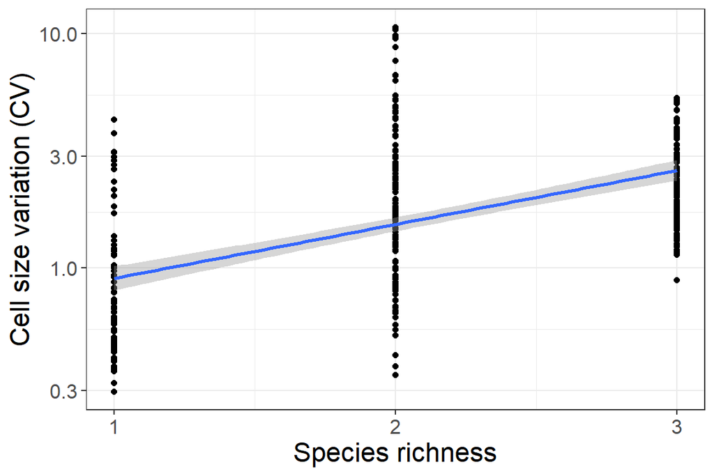

```r
# add this for nonlinear fit
# stat_smooth(method = "lm", formula = y ~ x + I(x^2))+

A <- ggplot(size_by_well, aes(species_richness, CV_biov))+
  geom_point()+
  #geom_smooth(method="lm")+
  stat_smooth(method = "lm")+
  xlab("Species richness")+
  ylab("Cell size variation (CV)")+
  scale_x_continuous(breaks=c(1,2,3))+
  scale_y_log10()
A
```

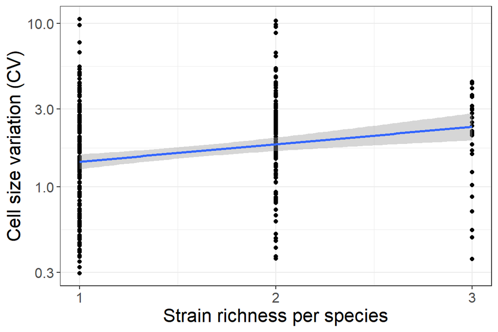

```r
B <- ggplot(size_by_well, aes(strains, CV_biov))+
  geom_point()+
  #geom_smooth(method="lm")+
  stat_smooth(method = "lm")+
  xlab("Strain richness per species")+
  ylab("Cell size variation (CV)")+
  scale_x_continuous(breaks=c(1,2,3))+
  scale_y_log10()
B
```

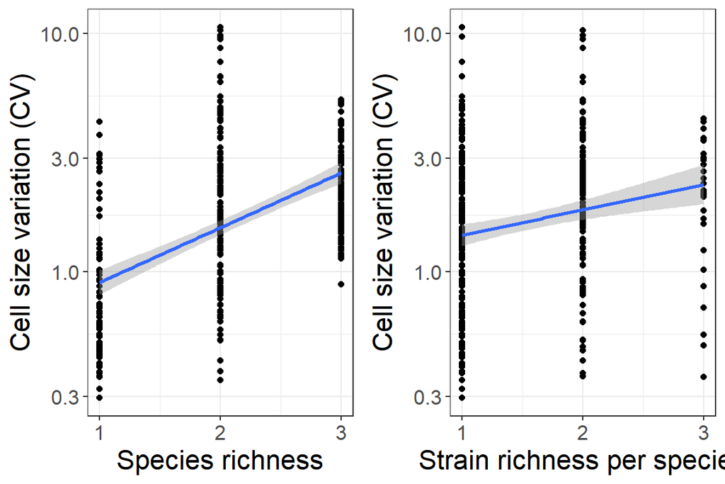

```r
ggarrange(A,B, common.legend=TRUE)
```

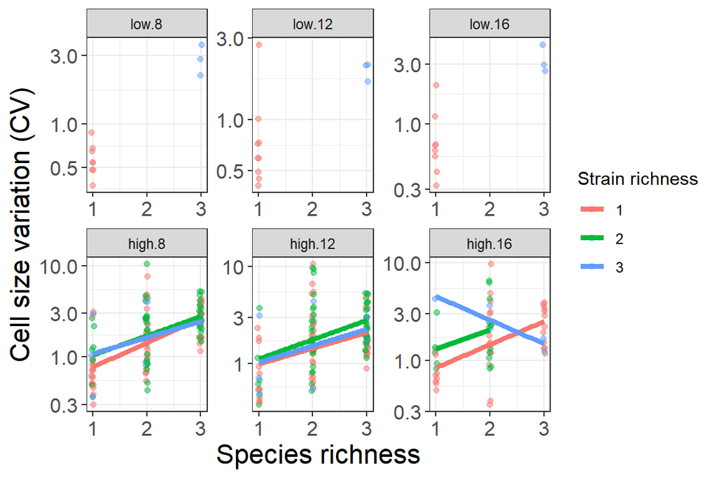

```r
ggplot(size_by_well, aes(species_richness, CV_biov))+
  geom_jitter(width = 0.02, alpha = 0.5,aes(color=as.factor(strains)))+
  geom_smooth(size = 1.5, se = FALSE, method = 'lm', aes(color = as.factor(strains)))+
  scale_y_log10()+
  facet_wrap(~nuts_temp, scales = 'free')+
  xlab("Species richness")+
  labs(color = "Strain richness")+
  scale_x_continuous(breaks=c(1,2,3))+
  ylab('Cell size variation (CV)')
```

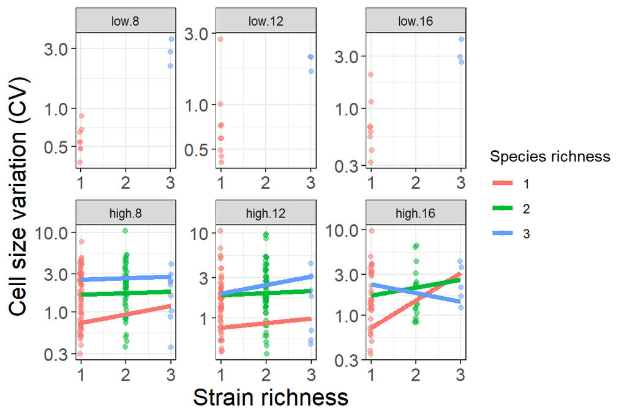

```r
ggplot(size_by_well, aes(strains, CV_biov))+
  geom_jitter(width = 0.02, alpha = 0.5,aes(color=as.factor(strains)))+
  geom_smooth(size = 1.5, se = FALSE, method = 'lm', aes(color = as.factor(species_richness)))+
  scale_y_log10()+
  facet_wrap(~nuts_temp, scales = 'free')+
  xlab("Strain richness")+
  labs(color = "Species richness")+
  scale_x_continuous(breaks=c(1,2,3))+
  ylab('Cell size variation (CV)')
```

```r
#
#
# ggplot(size_by_well, aes(nuts_temp, CV_biov))+
#   geom_boxplot()+
#   #geom_smooth(method="lm")+
#   xlab("Nutrient x temperature environment")+
#   ylab("Cell size variation (CV)")+
#   scale_y_log10()
#
```

## models

> models for CV size with varying interactions etc

```r
fit1 <- lm(data=size_by_well, CV_biov~species_richness*strains)
summary(fit1)
```

```
##
## Call:
## lm(formula = CV_biov ~ species_richness * strains, data = size_by_well)
##
## Residuals:
##     Min      1Q  Median      3Q     Max
## -1.9772 -0.9266 -0.4492  0.4828  8.7078
##
## Coefficients:
##                          Estimate Std. Error t value Pr(>|t|)
## (Intercept)               -0.4987     0.6032  -0.827   0.4090
## species_richness           1.0579     0.2680   3.948 9.59e-05 ***
## strains                    0.7680     0.3812   2.015   0.0447 *
## species_richness:strains  -0.2332     0.1629  -1.432   0.1532
## ---
## Signif. codes:  0 '***' 0.001 '**' 0.01 '*' 0.05 '.' 0.1 ' ' 1
##
## Residual standard error: 1.578 on 340 degrees of freedom
## Multiple R-squared:  0.1335, Adjusted R-squared:  0.1259
## F-statistic: 17.46 on 3 and 340 DF,  p-value: 1.446e-10
```

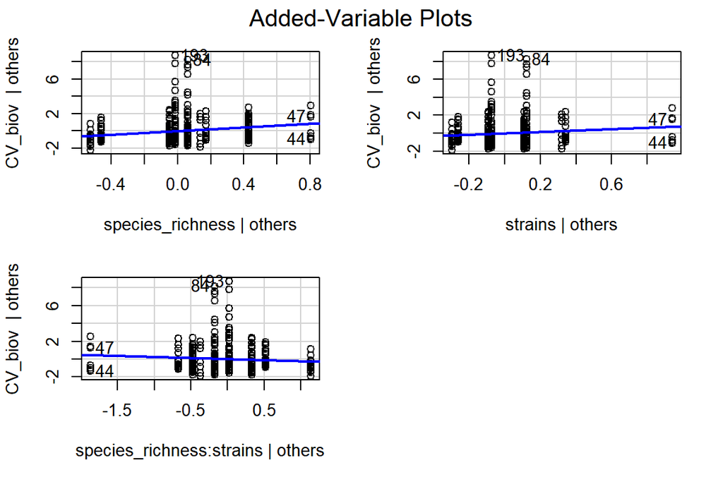

```r
avPlots(fit1)
```

```r
fit2 <- lm(data=size_by_well, CV_biov~species_richness*strains + temp + nuts)
summary(fit2)
```

```
##
## Call:
## lm(formula = CV_biov ~ species_richness * strains + temp + nuts,
##     data = size_by_well)
##
## Residuals:
##     Min      1Q  Median      3Q     Max
## -2.0073 -0.9319 -0.4195  0.4648  8.6474
##
## Coefficients:
##                           Estimate Std. Error t value Pr(>|t|)
## (Intercept)              -0.004256   0.711443  -0.006  0.99523
## species_richness          0.848490   0.309552   2.741  0.00645 **
## strains                   0.524438   0.420179   1.248  0.21285
## temp16                    0.103151   0.238048   0.433  0.66506
## temp8                    -0.076405   0.189920  -0.402  0.68772
## nutslow                  -0.467586   0.330998  -1.413  0.15868
## species_richness:strains -0.119019   0.182479  -0.652  0.51469
## ---
## Signif. codes:  0 '***' 0.001 '**' 0.01 '*' 0.05 '.' 0.1 ' ' 1
##
## Residual standard error: 1.579 on 337 degrees of freedom
## Multiple R-squared:  0.1397, Adjusted R-squared:  0.1244
## F-statistic: 9.119 on 6 and 337 DF,  p-value: 2.962e-09
```

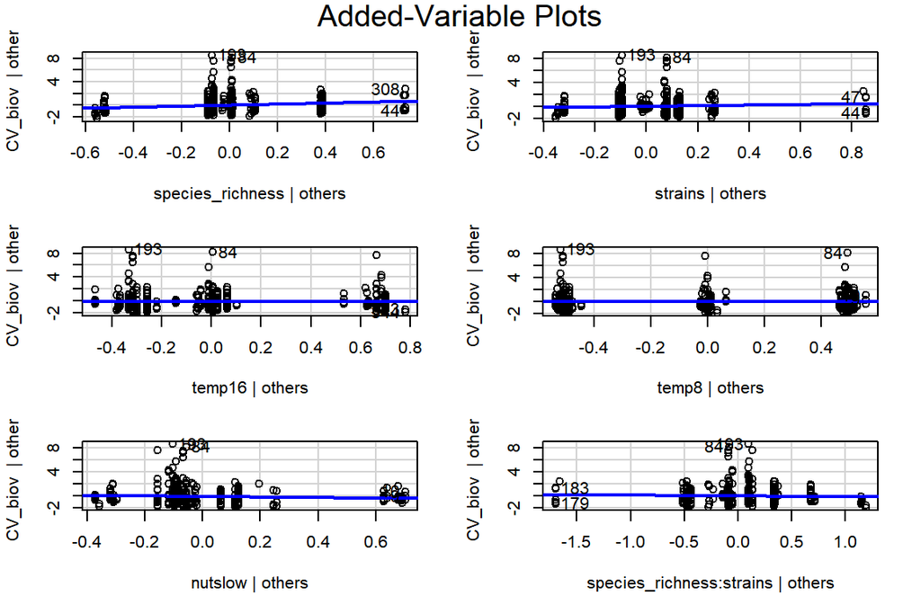

```r
avPlots(fit2)
```

```r
fit2.1 <- lm(data=size_by_well, CV_biov~species_richness*strains + temp*nuts)
summary(fit2.1)
```

```
##
## Call:
## lm(formula = CV_biov ~ species_richness * strains + temp * nuts,
##     data = size_by_well)
##
## Residuals:
##     Min      1Q  Median      3Q     Max
## -2.0161 -0.9357 -0.4099  0.4596  8.6369
##
## Coefficients:
##                           Estimate Std. Error t value Pr(>|t|)
## (Intercept)               0.007728   0.714577   0.011  0.99138
## species_richness          0.848199   0.310424   2.732  0.00662 **
## strains                   0.525445   0.421373   1.247  0.21327
## temp16                    0.071732   0.256769   0.279  0.78014
## temp8                    -0.086168   0.198928  -0.433  0.66518
## nutslow                  -0.577406   0.507407  -1.138  0.25595
## species_richness:strains -0.119949   0.183014  -0.655  0.51265
## temp16:nutslow            0.239208   0.709473   0.337  0.73621
## temp8:nutslow             0.109958   0.690402   0.159  0.87355
## ---
## Signif. codes:  0 '***' 0.001 '**' 0.01 '*' 0.05 '.' 0.1 ' ' 1
##
## Residual standard error: 1.583 on 335 degrees of freedom
## Multiple R-squared:   0.14,  Adjusted R-squared:  0.1194
## F-statistic: 6.815 on 8 and 335 DF,  p-value: 2.669e-08
```

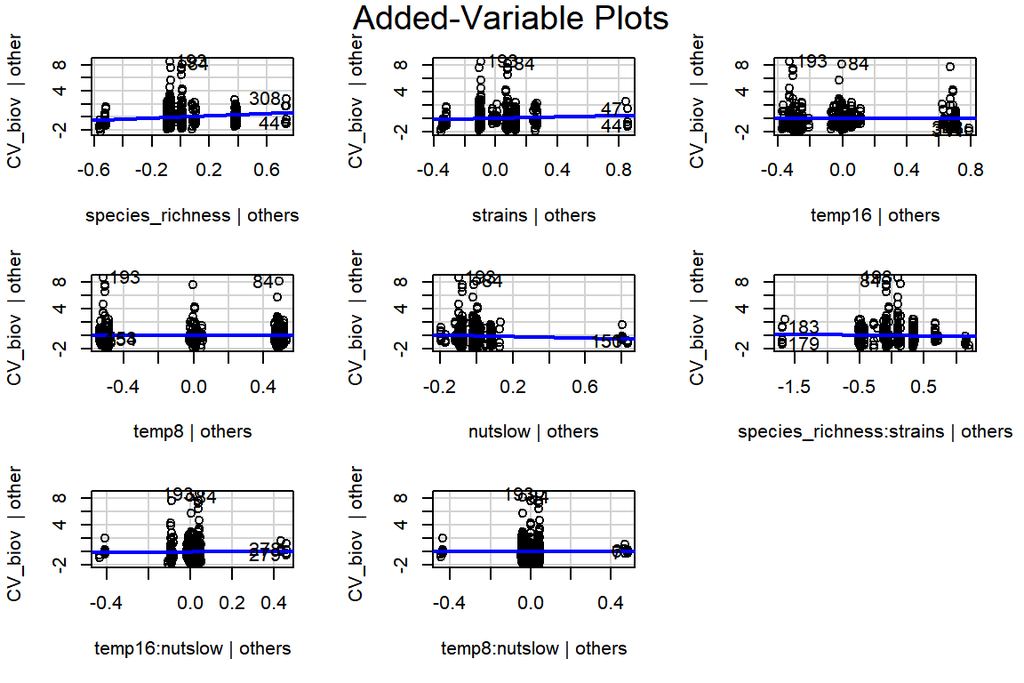

```r
avPlots(fit2.1)
```

```r
fit3 <- lm(data=size_by_well, CV_biov~species_richness + strains + temp + nuts)
summary(fit3)
```

```
##
## Call:
## lm(formula = CV_biov ~ species_richness + strains + temp + nuts,
##     data = size_by_well)
##
## Residuals:
##     Min      1Q  Median      3Q     Max
## -2.0526 -0.9383 -0.4201  0.4876  8.6358
##
## Coefficients:
##                  Estimate Std. Error t value Pr(>|t|)
## (Intercept)       0.40475    0.33573   1.206   0.2288
## species_richness  0.66086    0.11421   5.787 1.64e-08 ***
## strains           0.26428    0.13200   2.002   0.0461 *
## temp16            0.10787    0.23774   0.454   0.6503
## temp8            -0.07599    0.18976  -0.400   0.6891
## nutslow          -0.56446    0.29555  -1.910   0.0570 .
## ---
## Signif. codes:  0 '***' 0.001 '**' 0.01 '*' 0.05 '.' 0.1 ' ' 1
##
## Residual standard error: 1.578 on 338 degrees of freedom
## Multiple R-squared:  0.1386, Adjusted R-squared:  0.1259
## F-statistic: 10.88 on 5 and 338 DF,  p-value: 1.021e-09
```

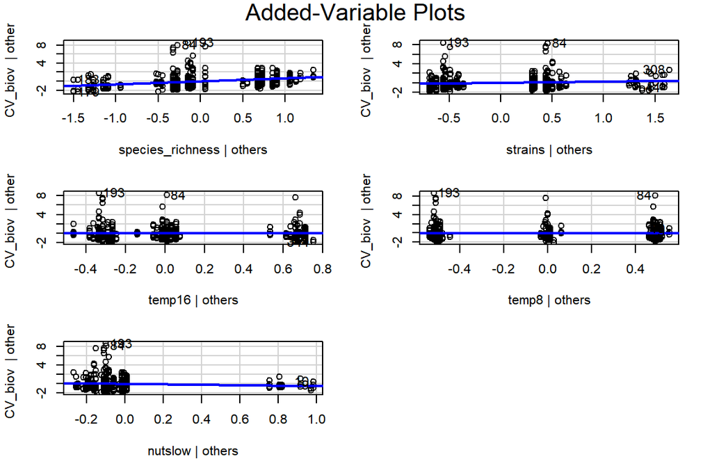

```r
avPlots(fit3)
```

```r
# or at least try something along these lines with lme4...

#fit3 <- lmer(data=size_by_well, CV_biov ~ species_richness + strains + 1|temp)
#summary(fit3)


AIC(fit1, fit2, fit2.1, fit3)
```

```
##        df      AIC
## fit1    5 1295.919
## fit2    8 1299.455
## fit2.1 10 1303.338
## fit3    7 1297.889
```

> models for variance in size (otherwise same as above)

```r
fit1 <- lm(data=size_by_well, var_biov~species_richness*strains)
summary(fit1)
```

```
##
## Call:
## lm(formula = var_biov ~ species_richness * strains, data = size_by_well)
##
## Residuals:
##        Min         1Q     Median         3Q        Max
## -4.832e+09 -2.728e+09 -1.224e+09 -3.932e+07  7.694e+10
##
## Coefficients:
##                            Estimate Std. Error t value Pr(>|t|)
## (Intercept)               8.164e+09  2.845e+09   2.870  0.00436 **
## species_richness         -2.452e+09  1.264e+09  -1.940  0.05315 .
## strains                  -1.313e+09  1.798e+09  -0.730  0.46578
## species_richness:strains  4.325e+08  7.683e+08   0.563  0.57386
## ---
## Signif. codes:  0 '***' 0.001 '**' 0.01 '*' 0.05 '.' 0.1 ' ' 1
##
## Residual standard error: 7.44e+09 on 340 degrees of freedom
## Multiple R-squared:  0.03875,    Adjusted R-squared:  0.03027
## F-statistic: 4.569 on 3 and 340 DF,  p-value: 0.003747
```

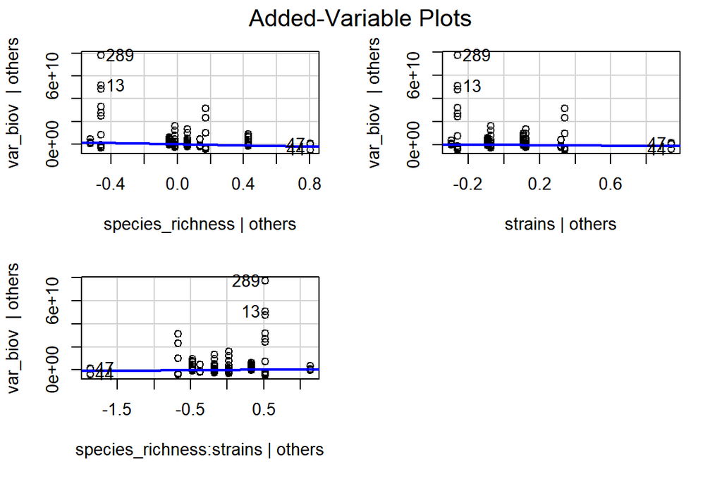

```r
avPlots(fit1)
```

```r
fit2 <- lm(data=size_by_well, var_biov~species_richness*strains + temp + nuts)
summary(fit2)
```

```
##
## Call:
## lm(formula = var_biov ~ species_richness * strains + temp + nuts,
##     data = size_by_well)
##
## Residuals:
##        Min         1Q     Median         3Q        Max
## -5.590e+09 -2.643e+09 -1.324e+09  3.390e+07  7.647e+10
##
## Coefficients:
##                            Estimate Std. Error t value Pr(>|t|)
## (Intercept)               7.578e+09  3.364e+09   2.253   0.0249 *
## species_richness         -2.260e+09  1.464e+09  -1.544   0.1234
## strains                  -1.129e+09  1.987e+09  -0.568   0.5703
## temp16                    7.517e+08  1.126e+09   0.668   0.5047
## temp8                    -4.344e+07  8.980e+08  -0.048   0.9614
## nutslow                   2.957e+08  1.565e+09   0.189   0.8502
## species_richness:strains  3.542e+08  8.628e+08   0.410   0.6817
## ---
## Signif. codes:  0 '***' 0.001 '**' 0.01 '*' 0.05 '.' 0.1 ' ' 1
##
## Residual standard error: 7.466e+09 on 337 degrees of freedom
## Multiple R-squared:  0.04055,    Adjusted R-squared:  0.02347
## F-statistic: 2.374 on 6 and 337 DF,  p-value: 0.02927
```

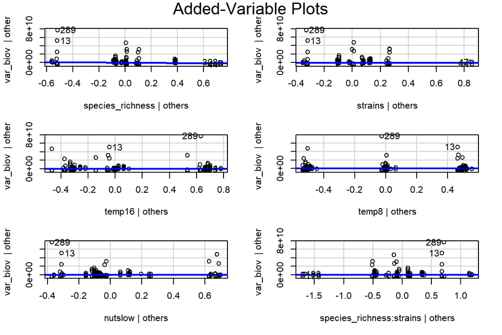

```r
avPlots(fit2)
```

```r
fit2.1 <- lm(data=size_by_well, var_biov~species_richness*strains + temp*nuts)
summary(fit2.1)
```

```
##
## Call:
## lm(formula = var_biov ~ species_richness * strains + temp * nuts,
##     data = size_by_well)
##
## Residuals:
##        Min         1Q     Median         3Q        Max
## -5.701e+09 -2.663e+09 -1.391e+09  2.620e+07  7.641e+10
##
## Coefficients:
##                            Estimate Std. Error t value Pr(>|t|)
## (Intercept)               7.479e+09  3.378e+09   2.214   0.0275 *
## species_richness         -2.258e+09  1.467e+09  -1.539   0.1248
## strains                  -1.132e+09  1.992e+09  -0.568   0.5701
## temp16                    9.090e+08  1.214e+09   0.749   0.4544
## temp8                     9.142e+07  9.403e+08   0.097   0.9226
## nutslow                   1.254e+09  2.399e+09   0.523   0.6015
## species_richness:strains  3.586e+08  8.651e+08   0.415   0.6788
## temp16:nutslow           -1.387e+09  3.354e+09  -0.413   0.6795
## temp8:nutslow            -1.597e+09  3.264e+09  -0.489   0.6249
## ---
## Signif. codes:  0 '***' 0.001 '**' 0.01 '*' 0.05 '.' 0.1 ' ' 1
##
## Residual standard error: 7.485e+09 on 335 degrees of freedom
## Multiple R-squared:  0.04136,    Adjusted R-squared:  0.01847
## F-statistic: 1.807 on 8 and 335 DF,  p-value: 0.07482
```

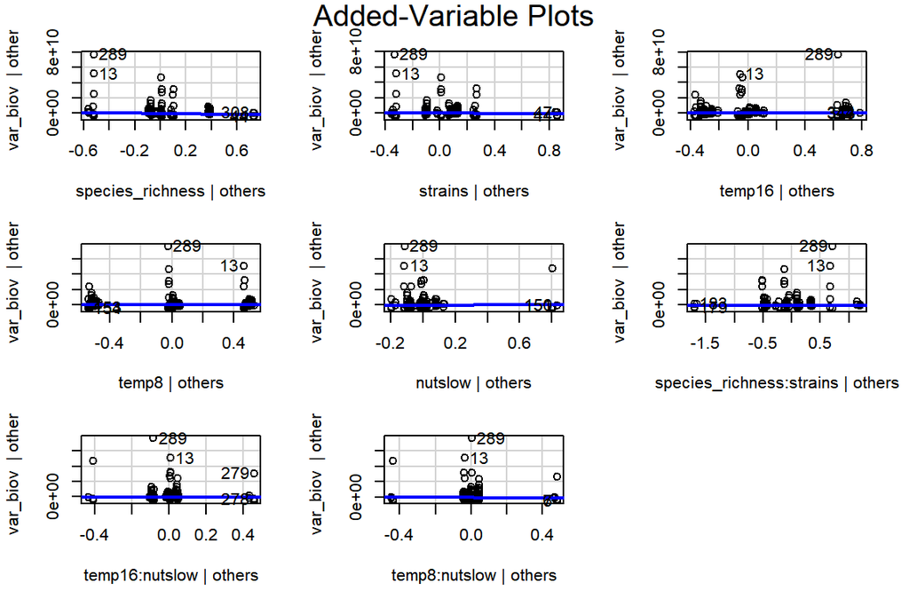

```r
avPlots(fit2.1)
```

```r
fit3 <- lm(data=size_by_well, var_biov~species_richness + strains + temp + nuts)
summary(fit3)
```

```
##
## Call:
## lm(formula = var_biov ~ species_richness + strains + temp + nuts,
##     data = size_by_well)
##
## Residuals:
##        Min         1Q     Median         3Q        Max
## -5.625e+09 -2.692e+09 -1.356e+09  3.062e+07  7.673e+10
##
## Coefficients:
##                    Estimate Std. Error t value Pr(>|t|)
## (Intercept)       6.361e+09  1.587e+09   4.009 7.51e-05 ***
## species_richness -1.702e+09  5.398e+08  -3.153  0.00176 **
## strains          -3.546e+08  6.239e+08  -0.568  0.57013
## temp16            7.376e+08  1.124e+09   0.656  0.51197
## temp8            -4.467e+07  8.969e+08  -0.050  0.96031
## nutslow           5.840e+08  1.397e+09   0.418  0.67615
## ---
## Signif. codes:  0 '***' 0.001 '**' 0.01 '*' 0.05 '.' 0.1 ' ' 1
##
## Residual standard error: 7.457e+09 on 338 degrees of freedom
## Multiple R-squared:  0.04007,    Adjusted R-squared:  0.02587
## F-statistic: 2.822 on 5 and 338 DF,  p-value: 0.01636
```

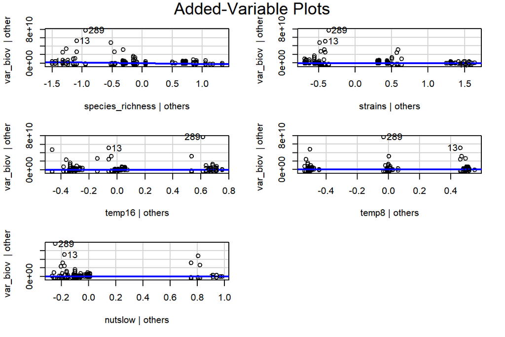

```r
avPlots(fit3)
```

```r
# or at least try something along these lines with lme4...

#fit3 <- lmer(data=size_by_well, CV_biov ~ species_richness + strains + 1|temp)
#summary(fit3)


AIC(fit1, fit2, fit2.1, fit3)
```

```
##        df      AIC
## fit1    5 16620.54
## fit2    8 16625.90
## fit2.1 10 16629.61
## fit3    7 16624.07
```